# Sunil Ex17 Global differential expression & GSEA

Camilo Posso

09/13/2021

# Introduction

Below we have the metadata for this experiment. We have a total of 30 samples and 2319 proteins. The samples are split in two ways: there are `Pre` and `Post` treatment groups, as well as 3 cell types, `CD14`, `CD34` and `MNC`. In this initial analysis we compare the `Pre` and `Post` groups within each cell type and across cell types, we also compare each pair of cell types to each other.

|  | PatientID | CellType | Trametinib | CellCount | Date |
| --- | --- | --- | --- | --- | --- |
| DIA_1E_Pre_CD14_A | 3434172 | CD14 | Pre | 700000 | 15-Jun |
| DIA_2C_Post_CD34 | 3585846 | CD34 | Post | 100000 | 18-Jun |
| DIA_6A_Post_MNC | 3577040 | MNC | Post | 250000 | 24-Jun |
| DIA_10C_Post_MNC | 3620420 | MNC | Post | 477000 | 24-Jun |
| DIA_1E_Pre_MNC | 3434172 | MNC | Pre | 250000 | 15-Jun |
| DIA_1F_Post_CD14_A | 3434172 | CD14 | Post | 624000 | 15-Jun |
| DIA_5C_Post_CD34 | 3570806 | CD34 | Post | 97300 | 15-Jun |
| DIA_1E_Pre_CD34_A | 3434172 | CD34 | Pre | 170000 | 15-Jun |
| DIA_2B_Pre_CD14 | 3585846 | CD14 | Pre | 33700 | 18-Jun |
| DIA_6A_Post_CD34 | 3577040 | CD34 | Post | 621000 | 24-Jun |
| DIA_10D_Pre_MNC | 3620420 | MNC | Pre | 319000 | 24-Jun |
| DIA_1E_Pre_CD14_B | 3434172 | CD14 | Pre | NaN | 28-Jun |
| DIA_1F_Post_MNC | 3434172 | MNC | Post | 250000 | 15-Jun |
| DIA_2B_Pre_CD34 | 3585846 | CD34 | Pre | 66200 | 18-Jun |
| DIA_2C_Post_CD14 | 3585846 | CD14 | Post | 51000 | 18-Jun |
| DIA_4E_Post_MNC | 3673634 | MNC | Post | 620000 | 24-Jun |
| DIA_4F_Pre_MNC | 3673634 | MNC | Pre | 46000 | 24-Jun |
| DIA_5B_Pre_CD14 | 3570806 | CD14 | Pre | 170000 | 15-Jun |
| DIA_5B_Pre_CD34 | 3570806 | CD34 | Pre | 312000 | 15-Jun |
| DIA_5C_Post_CD14 | 3570806 | CD14 | Post | 293000 | 15-Jun |
| DIA_6A_Post_CD14 | 3577040 | CD14 | Post | 122000 | 24-Jun |
| DIA_6B_Pre_CD34 | 3577040 | CD34 | Pre | 111000 | 24-Jun |
| DIA_6B_Pre_MNC | 3577040 | MNC | Pre | 250000 | 24-Jun |
| DIA_8A_Post_MNC | 3850130 | MNC | Post | 225000 | 21-Jun |
| DIA_8B_Pre_MNC | 3850130 | MNC | Pre | 1600000 | 21-Jun |
| DIA_9A_Pre_CD34 | 3668110 | CD34 | Pre | 71900 | 18-Jun |
| DIA_9B_Post_CD34 | 3668110 | CD34 | Post | 23200 | 18-Jun |
| DIA_1F_Post_CD34_B | 3434172 | CD34 | Post | NaN | 28-Jun |
| DIA_1E_Pre_CD34_B | 3434172 | CD34 | Pre | NaN | 28-Jun |
| DIA_9A_Pre_CD14 | 3668110 | CD14 | Pre | 46700 | 18-Jun |

$$\\[.2in]$$

# Missing data

First, notice the large amount of missing values present. Below we summarize the distribution of NA values in the data by counting the number of missing intensities per feature.

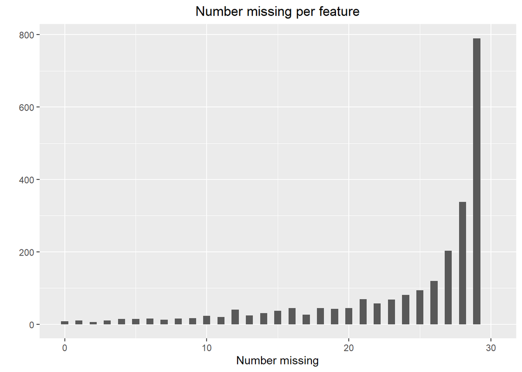

```r
missing <- rowSums(is.na(prot.mat))
dff = data.frame(missing = missing)

breaks = seq(-0.25, ncol(prot.mat) + 0.25, 0.5)

p1 <- ggplot(dff, aes(x = missing)) + geom_histogram(breaks = breaks) +
  ylab("") + xlab("Number missing") +
  ggtitle("Number missing per feature") +
  theme(plot.title = element_text(hjust = 0.5))
p1
```

We have 2 treatment groups `Pre` and `Post`, as well as 3 cell types `CD14`, `CD34` and `MNC`. Below we further restrict to these groups when counting the number of missing values per feature.

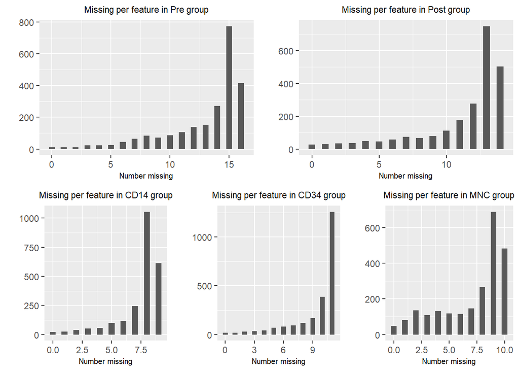

```r
layout <- rbind(c(1,1,1,2,2,2),
                c(3,3,4,4,5,5))
grid.arrange(grobs = plots, layout_matrix = layout)
```

$$\\[.2in]$$

# PCA plots

Below we collect two PCA plots for this data,

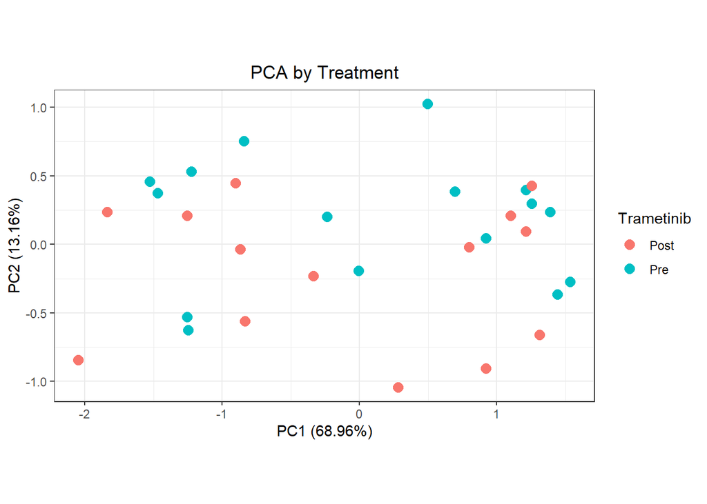

```r
p <- plot_pca_v4(m, "Trametinib", show.ellipse = F) +
  ggtitle("PCA by Treatment") +
  theme(plot.title = element_text(size = 13, hjust = 0.5))

p
```

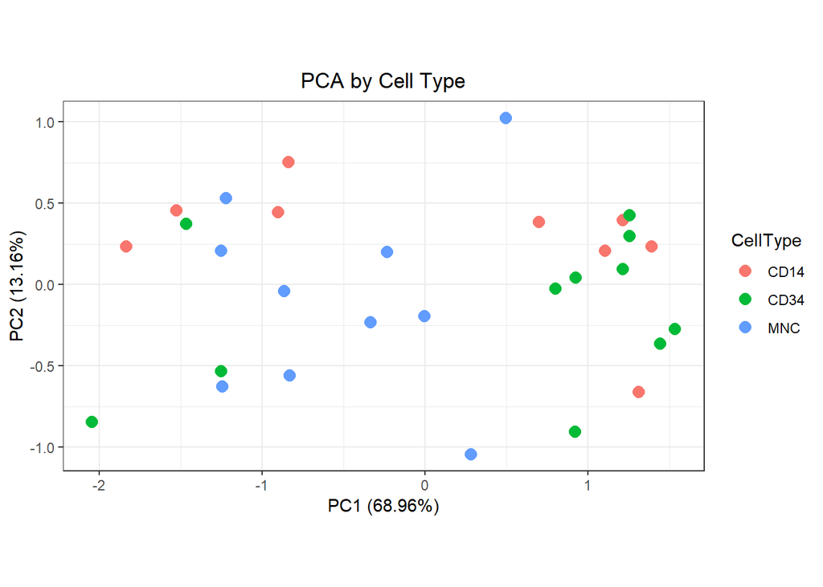

```r
p <- plot_pca_v4(m, "CellType", show.ellipse = F) +
  ggtitle("PCA by Cell Type") +
  theme(plot.title = element_text(size = 13, hjust = 0.5))

p
```

$$\\[.2in]$$

# Pre-Trametinib vs Post-Trametinib

Next, we compare the Pre and Post treatment groups within each cell type individually. Due to the large amount of missing data, we first restrict the samples by cell type, then filter the features such that at most 60% of the data is missing within that cell type.

$$\\[.1in]$$

### CD14 Cell Type

Restricting to those `CD14` cell types, we then filter out all features with more than 0.6% of the data missing within the `CD14` group.

Using these features, we compare the pre and post-treatment group using differential expression and rank based GSEA with the KEGG database.

```r
show <- diff.results[["CD14"]] %>%
  select(-featureID, -t, -B, -AveExpr) %>% head(.)
kbl(show) %>%
  kable_paper("hover", full_width = F)
```

|  | value | P.Value | adj.P.Val |
| --- | --- | --- | --- |
| O15355 | -9.966667 | 0.0055886 | 0.916303 |
| P39687 | -7.582667 | 0.0138898 | 0.916303 |
| Q01130 | -6.538350 | 0.0187610 | 0.916303 |
| O00299 | -6.104533 | 0.0205890 | 0.916303 |
| Q14566 | -7.595933 | 0.0287578 | 0.916303 |
| Q01469 | -5.621550 | 0.0309657 | 0.916303 |

As no pathway showed significant enrichment, we show the most significantly enriched pathways instead.

```r
show <- gsea.results[["CD14"]] %>%
  select(Description, setSize, NES, pvalue, p.adjust) %>%
  head(10)

kbl(show) %>%
  kable_paper("hover", full_width = T)
```

|  | Description | setSize | NES | pvalue | p.adjust |
| --- | --- | --- | --- | --- | --- |
| hsa05022 | Pathways of neurodegeneration - multiple diseases | 18 | -1.446238 | 0.0336735 | 0.7408163 |
| hsa04144 | Endocytosis | 13 | -1.302189 | 0.1181347 | 0.8041889 |
| hsa05012 | Parkinson disease | 15 | -1.288622 | 0.1208678 | 0.8041889 |
| hsa04714 | Thermogenesis | 11 | -1.195495 | 0.2068230 | 0.8041889 |
| hsa05168 | Herpes simplex virus 1 infection | 10 | -1.151003 | 0.2664509 | 0.8041889 |
| hsa04141 | Protein processing in endoplasmic reticulum | 17 | -1.156545 | 0.2738462 | 0.8041889 |
| hsa03040 | Spliceosome | 20 | -1.119676 | 0.3112245 | 0.8041889 |
| hsa01200 | Carbon metabolism | 13 | -1.091506 | 0.3502591 | 0.8041889 |
| hsa05016 | Huntington disease | 12 | -1.087076 | 0.3605870 | 0.8041889 |
| hsa04530 | Tight junction | 12 | -1.051296 | 0.4171908 | 0.8041889 |

$$\\[.1in]$$

## CD34 Cell Type

Restricting to those `CD34` cell types, we then filter out all features with more than 0.6% of the data missing within the `CD34` group.

Using these features, we compare the pre and post-treatment group using differential expression and rank based GSEA with the KEGG database.

```r
show <- diff.results[["CD34"]] %>%
  select(-featureID, -t, -B, -AveExpr) %>% head(.)
kbl(show) %>%
  kable_paper("hover", full_width = F)
```

|  | value | P.Value | adj.P.Val |
| --- | --- | --- | --- |
| P39687 | -9.191800 | 0.0002562 | 0.0748018 |
| P53999 | -7.546617 | 0.0008556 | 0.1249174 |
| O00299 | -6.968633 | 0.0042534 | 0.4140019 |
| P26583 | -4.757833 | 0.0100058 | 0.7121628 |
| P61247 | -5.765475 | 0.0163353 | 0.7121628 |
| P35527 | 4.957933 | 0.0167537 | 0.7121628 |

As no pathway showed significant enrichment, we show the most significantly enriched pathways instead.

```r
show <- gsea.results[["CD34"]] %>%
  select(Description, setSize, NES, pvalue, p.adjust) %>%
  head(10)

kbl(show) %>%
  kable_paper("hover", full_width = T)
```

|  | Description | setSize | NES | pvalue | p.adjust |
| --- | --- | --- | --- | --- | --- |
| hsa04530 | Tight junction | 11 | -1.579237 | 0.0239778 | 0.2978045 |
| hsa05415 | Diabetic cardiomyopathy | 15 | 1.526216 | 0.0369909 | 0.2978045 |
| hsa01230 | Biosynthesis of amino acids | 10 | -1.454934 | 0.0410765 | 0.2978045 |
| hsa05130 | Pathogenic Escherichia coli infection | 10 | -1.457391 | 0.0410765 | 0.2978045 |
| hsa05208 | Chemical carcinogenesis - reactive oxygen species | 13 | 1.537336 | 0.0553912 | 0.3212689 |
| hsa05014 | Amyotrophic lateral sclerosis | 28 | -1.390288 | 0.0738916 | 0.3385437 |
| hsa04145 | Phagosome | 14 | -1.404015 | 0.0817175 | 0.3385437 |
| hsa05132 | Salmonella infection | 14 | -1.358596 | 0.1094183 | 0.3545559 |
| hsa04810 | Regulation of actin cytoskeleton | 13 | -1.350527 | 0.1171548 | 0.3545559 |
| hsa04141 | Protein processing in endoplasmic reticulum | 17 | 1.318782 | 0.1450980 | 0.3545559 |

$$\\[.1in]$$

## MNC Cell Type

Restricting to those `MNC` cell types, we then filter out all features with more than 0.6% of the data missing within the `MNC` group.

Using these features, we compare the pre and post-treatment group using differential expression and rank based GSEA with the KEGG database.

```r
show <- diff.results[["MNC"]] %>%
  select(-featureID, -t, -B, -AveExpr) %>% head(.)
kbl(show) %>%
  kable_paper("hover", full_width = F)
```

|  | value | P.Value | adj.P.Val |
| --- | --- | --- | --- |
| Q9Y4G6 | 9.224750 | 0.0005429 | 0.3995641 |
| Q13200 | -7.959867 | 0.0030417 | 0.9983801 |
| P07339 | 6.837667 | 0.0054082 | 0.9983801 |
| Q9P258 | 3.928600 | 0.0085031 | 0.9983801 |
| P42765 | 6.366000 | 0.0104393 | 0.9983801 |
| P52907 | 2.430800 | 0.0125270 | 0.9983801 |

As no pathway showed significant enrichment, we show the most significantly enriched pathways instead.

```r
show <- gsea.results[["MNC"]] %>%
  select(Description, setSize, NES, pvalue, p.adjust) %>%
  head(10)

kbl(show) %>%
  kable_paper("hover", full_width = T)
```

|  | Description | setSize | NES | pvalue | p.adjust |
| --- | --- | --- | --- | --- | --- |
| hsa05132 | Salmonella infection | 35 | -1.823643 | 0.0024518 | 0.2108555 |
| hsa05020 | Prion disease | 40 | -1.609673 | 0.0111754 | 0.4805433 |
| hsa05010 | Alzheimer disease | 40 | -1.513099 | 0.0228041 | 0.5584416 |
| hsa05012 | Parkinson disease | 38 | -1.424175 | 0.0302872 | 0.5584416 |
| hsa04530 | Tight junction | 28 | -1.461006 | 0.0463984 | 0.5584416 |
| hsa05016 | Huntington disease | 38 | -1.349839 | 0.0533038 | 0.5584416 |
| hsa05135 | Yersinia infection | 18 | -1.529784 | 0.0620232 | 0.5584416 |
| hsa04110 | Cell cycle | 12 | 1.417046 | 0.0706806 | 0.5584416 |
| hsa04810 | Regulation of actin cytoskeleton | 36 | -1.311761 | 0.0754274 | 0.5584416 |
| hsa05205 | Proteoglycans in cancer | 21 | -1.484857 | 0.0824976 | 0.5584416 |

$$\\[.1in]$$

## Pre vs Post (All cell types)

We also compare the two treatment groups without restricting the cell type. We still filter out all features with more than 0.6% of the data missing.

```r
show <- limma %>%
  select(-featureID, -t, -B, -AveExpr) %>% head(.)
kbl(show) %>%
  kable_paper("hover", full_width = F)
```

|  | value | P.Value | adj.P.Val |
| --- | --- | --- | --- |
| P39687 | -6.134210 | 0.0039662 | 0.9933705 |
| O00299 | -4.010490 | 0.0073560 | 0.9933705 |
| P0DP23 | -2.153001 | 0.0250303 | 0.9933705 |
| O15355 | -2.873162 | 0.0312852 | 0.9933705 |
| Q01130 | -2.477968 | 0.0314729 | 0.9933705 |
| P33176 | -3.735710 | 0.0322873 | 0.9933705 |

As no pathway showed significant enrichment, we show the most significantly enriched pathways instead.

```r
show <- rank.GSEA %>%
  select(Description, setSize, NES, pvalue, p.adjust) %>%
  head(10)

kbl(show) %>%
  kable_paper("hover", full_width = T)
```

|  | Description | setSize | NES | pvalue | p.adjust |
| --- | --- | --- | --- | --- | --- |
| hsa05010 | Alzheimer disease | 22 | -1.641662 | 0.0064746 | 0.2913560 |
| hsa05132 | Salmonella infection | 23 | -1.560268 | 0.0139190 | 0.3131764 |
| hsa05012 | Parkinson disease | 25 | -1.510006 | 0.0226971 | 0.3404558 |
| hsa05016 | Huntington disease | 22 | -1.475441 | 0.0334101 | 0.3758641 |
| hsa04210 | Apoptosis | 10 | 1.620382 | 0.0453457 | 0.4081115 |
| hsa05022 | Pathways of neurodegeneration - multiple diseases | 29 | -1.401167 | 0.0571109 | 0.4283315 |
| hsa00010 | Glycolysis / Gluconeogenesis | 11 | -1.361260 | 0.0937896 | 0.5312145 |
| hsa05168 | Herpes simplex virus 1 infection | 11 | -1.357915 | 0.0950570 | 0.5312145 |
| hsa04666 | Fc gamma R-mediated phagocytosis | 12 | -1.318828 | 0.1171393 | 0.5312145 |
| hsa05020 | Prion disease | 25 | -1.305970 | 0.1180477 | 0.5312145 |

$$\\[.2in]$$

# Comparing Cell Types

Finally, we compare all the cell types to each other, pair by pair. We again use differential expression and GSEA with the KEGG database in order to compare the groups.

$$\\[.1in]$$

## CD14 vs CD34

First, we remove the `MNC` samples, then we filter out all features with more than 0.6% of the data missing within.

Using these features, we compare the `CD14` and `CD34` cell types using differential expression and rank based GSEA with the KEGG database.

```r
show <- limma.results[["MNC"]] %>%
  select(-featureID, -t, -B, -AveExpr) %>% head(.)
kbl(show) %>%
  kable_paper("hover", full_width = F)
```

|  | logFC | P.Value | adj.P.Val |
| --- | --- | --- | --- |
| P26447 | -4.713114 | 0.0122329 | 0.9899229 |
| P20674 | -7.083433 | 0.0163331 | 0.9899229 |
| P06576 | 3.694239 | 0.0223781 | 0.9899229 |
| Q14847 | -3.776858 | 0.0359544 | 0.9899229 |
| P60953 | -3.789153 | 0.0427790 | 0.9899229 |
| Q09666 | -3.891575 | 0.0500519 | 0.9899229 |

As no pathway showed significant enrichment, we show the most significantly enriched pathways instead. Positive NES scores indicate increased activity in the `CD34` samples.

```r
show <- gsea.results[["MNC"]] %>%
  select(Description, setSize, NES, pvalue, p.adjust) %>%
  head(10)

kbl(show) %>%
  kable_paper("hover", full_width = T)
```

|  | Description | setSize | NES | pvalue | p.adjust |
| --- | --- | --- | --- | --- | --- |
| hsa05132 | Salmonella infection | 16 | -1.421187 | 0.0814286 | 0.708502 |
| hsa04530 | Tight junction | 13 | -1.422388 | 0.0861314 | 0.708502 |
| hsa04810 | Regulation of actin cytoskeleton | 14 | -1.425836 | 0.0889527 | 0.708502 |
| hsa04510 | Focal adhesion | 10 | -1.365665 | 0.1328244 | 0.708502 |
| hsa01230 | Biosynthesis of amino acids | 10 | -1.276792 | 0.1816794 | 0.708502 |
| hsa05130 | Pathogenic Escherichia coli infection | 12 | -1.238644 | 0.2154532 | 0.708502 |
| hsa04670 | Leukocyte transendothelial migration | 10 | -1.218290 | 0.2259542 | 0.708502 |
| hsa05131 | Shigellosis | 13 | -1.210650 | 0.2408759 | 0.708502 |
| hsa05203 | Viral carcinogenesis | 14 | -1.175724 | 0.2668580 | 0.708502 |
| hsa05012 | Parkinson disease | 20 | -1.160324 | 0.2922438 | 0.708502 |

$$\\[.1in]$$

## CD34 vs MNC

First, we remove the `CD14` samples, then we filter out all features with more than 0.6% of the data missing within.

Using these features, we compare the `CD34` and `MNC` cell types using differential expression and rank based GSEA with the KEGG database.

```r
show <- limma.results[["CD14"]] %>%
  select(-featureID, -t, -B, -AveExpr) %>% head(.)
kbl(show) %>%
  kable_paper("hover", full_width = F)
```

|  | logFC | P.Value | adj.P.Val |
| --- | --- | --- | --- |
| P08575 | 8.914929 | 0.0000109 | 0.0049497 |
| P68431 | 3.323230 | 0.0001115 | 0.0254205 |
| Q15942 | 4.234881 | 0.0002655 | 0.0403513 |
| O00571 | 4.761100 | 0.0005260 | 0.0501301 |
| Q15057 | 4.964781 | 0.0006568 | 0.0501301 |
| P62805 | 3.369979 | 0.0007562 | 0.0501301 |

```r
show <- gsea.results[["CD14"]] %>%
  select(Description, setSize, NES, pvalue, p.adjust) %>%
  head(10)

kbl(show) %>%
  kable_paper("hover", full_width = T)
```

|  | Description | setSize | NES | pvalue | p.adjust |
| --- | --- | --- | --- | --- | --- |
| hsa04145 | Phagosome | 19 | 1.806755 | 0.0004225 | 0.0223942 |
| hsa04510 | Focal adhesion | 15 | 1.719882 | 0.0035336 | 0.0842977 |
| hsa04530 | Tight junction | 20 | 1.663077 | 0.0047716 | 0.0842977 |
| hsa05132 | Salmonella infection | 25 | 1.518148 | 0.0184129 | 0.1848244 |
| hsa04810 | Regulation of actin cytoskeleton | 22 | 1.546793 | 0.0206268 | 0.1848244 |
| hsa04670 | Leukocyte transendothelial migration | 17 | 1.523788 | 0.0240492 | 0.1848244 |
| hsa05205 | Proteoglycans in cancer | 11 | 1.531996 | 0.0250039 | 0.1848244 |
| hsa04611 | Platelet activation | 11 | 1.501493 | 0.0300429 | 0.1848244 |
| hsa04390 | Hippo signaling pathway | 10 | 1.512828 | 0.0313853 | 0.1848244 |
| hsa05130 | Pathogenic Escherichia coli infection | 20 | 1.453778 | 0.0369231 | 0.1882500 |

$$\\[.1in]$$

## CD14 vs MNC

First, we remove the `CD34` samples, then we filter out all features with more than 0.6% of the data missing within.

Using these features, we compare the `CD14` and `MNC` cell types using differential expression and rank based GSEA with the KEGG database.

```r
show <- limma.results[["CD34"]] %>%
  select(-featureID, -t, -B, -AveExpr) %>% head(.)
kbl(show) %>%
  kable_paper("hover", full_width = F)
```

|  | logFC | P.Value | adj.P.Val |
| --- | --- | --- | --- |
| P68431 | 4.725071 | 0.0000638 | 0.0313345 |
| P62805 | 4.144096 | 0.0001955 | 0.0480037 |
| P04839 | -10.220057 | 0.0004898 | 0.0801631 |
| Q15057 | 6.094589 | 0.0009432 | 0.1062219 |
| P06576 | 5.390962 | 0.0010817 | 0.1062219 |
| P16104 | 3.654500 | 0.0017549 | 0.1241143 |

As no pathway showed significant enrichment, we show the most significantly enriched pathways instead. Positive NES scores indicate increased activity in the `MNC` samples.

```r
show <- gsea.results[["CD34"]] %>%
  select(Description, setSize, NES, pvalue, p.adjust) %>%
  head(10)

kbl(show) %>%
  kable_paper("hover", full_width = T)
```

|  | Description | setSize | NES | pvalue | p.adjust |
| --- | --- | --- | --- | --- | --- |
| hsa05034 | Alcoholism | 11 | 1.710825 | 0.0036666 | 0.2126641 |
| hsa05322 | Systemic lupus erythematosus | 12 | 1.608754 | 0.0155183 | 0.4500301 |
| hsa05100 | Bacterial invasion of epithelial cells | 16 | -1.506603 | 0.0521240 | 0.7374406 |
| hsa03040 | Spliceosome | 32 | 1.384121 | 0.0717489 | 0.7374406 |
| hsa05417 | Lipid and atherosclerosis | 14 | -1.486860 | 0.0720764 | 0.7374406 |
| hsa04520 | Adherens junction | 10 | -1.472376 | 0.0777660 | 0.7374406 |
| hsa05171 | Coronavirus disease - COVID-19 | 27 | -1.358449 | 0.1039316 | 0.7374406 |
| hsa03015 | mRNA surveillance pathway | 10 | -1.383855 | 0.1118340 | 0.7374406 |
| hsa04670 | Leukocyte transendothelial migration | 19 | -1.365581 | 0.1144304 | 0.7374406 |
| hsa05135 | Yersinia infection | 11 | -1.392456 | 0.1337249 | 0.7756042 |